# RedWine Analysis By Gaganpreet Singh

```r
#load all the required libraries
library(ggplot2)
library(GGally)
library(memisc)
library(psych)
```

# Target of the Project

In this project, i am trying to analyze the which of the factors determine the quality of the red wine. After analysis, i will create a linear model to predict the quality of wine for given characteristics.

# Structure of Dataframe

```r
dim(redwine)
```

```
## [1] 1599   13
```

Our data set consists of 13 variables that may determine Red wine quality with around 1600 observations.

# Summary of the Data Frame

```r
#checking datatype of various varibles in dataset
str(redwine)
```

```
## 'data.frame':    1599 obs. of  13 variables:
##  $ X                   : int  1 2 3 4 5 6 7 8 9 10 ...
##  $ fixed.acidity       : num  7.4 7.8 7.8 11.2 7.4 7.4 7.9 7.3 7.8 7.5 ...
##  $ volatile.acidity    : num  0.7 0.88 0.76 0.28 0.7 0.66 0.6 0.65 0.58 0.5 ...
##  $ citric.acid         : num  0 0 0.04 0.56 0 0 0.06 0 0.02 0.36 ...
##  $ residual.sugar      : num  1.9 2.6 2.3 1.9 1.9 1.8 1.6 1.2 2 6.1 ...
##  $ chlorides           : num  0.076 0.098 0.092 0.075 0.076 0.075 0.069 0.065 0.073 0.071 ...
##  $ free.sulfur.dioxide : num  11 25 15 17 11 13 15 15 9 17 ...
##  $ total.sulfur.dioxide: num  34 67 54 60 34 40 59 21 18 102 ...
##  $ density             : num  0.998 0.997 0.997 0.998 0.998 ...
##  $ pH                  : num  3.51 3.2 3.26 3.16 3.51 3.51 3.3 3.39 3.36 3.35 ...
##  $ sulphates           : num  0.56 0.68 0.65 0.58 0.56 0.56 0.46 0.47 0.57 0.8 ...
##  $ alcohol             : num  9.4 9.8 9.8 9.8 9.4 9.4 9.4 10 9.5 10.5 ...
##  $ quality             : int  5 5 5 6 5 5 5 7 7 5 ...
```

```r
#descriptive statistics of the data
summary(redwine)
```

```
##        X          fixed.acidity   volatile.acidity  citric.acid
##  Min.   :   1.0   Min.   : 4.60   Min.   :0.1200   Min.   :0.000
##  1st Qu.: 400.5   1st Qu.: 7.10   1st Qu.:0.3900   1st Qu.:0.090
##  Median : 800.0   Median : 7.90   Median :0.5200   Median :0.260
##  Mean   : 800.0   Mean   : 8.32   Mean   :0.5278   Mean   :0.271
##  3rd Qu.:1199.5   3rd Qu.: 9.20   3rd Qu.:0.6400   3rd Qu.:0.420
##  Max.   :1599.0   Max.   :15.90   Max.   :1.5800   Max.   :1.000
##  residual.sugar     chlorides       free.sulfur.dioxide
##  Min.   : 0.900   Min.   :0.01200   Min.   : 1.00
##  1st Qu.: 1.900   1st Qu.:0.07000   1st Qu.: 7.00
##  Median : 2.200   Median :0.07900   Median :14.00
##  Mean   : 2.539   Mean   :0.08747   Mean   :15.87
##  3rd Qu.: 2.600   3rd Qu.:0.09000   3rd Qu.:21.00
##  Max.   :15.500   Max.   :0.61100   Max.   :72.00
##  total.sulfur.dioxide    density             pH          sulphates
##  Min.   :  6.00       Min.   :0.9901   Min.   :2.740   Min.   :0.3300
##  1st Qu.: 22.00       1st Qu.:0.9956   1st Qu.:3.210   1st Qu.:0.5500
##  Median : 38.00       Median :0.9968   Median :3.310   Median :0.6200
##  Mean   : 46.47       Mean   :0.9967   Mean   :3.311   Mean   :0.6581
##  3rd Qu.: 62.00       3rd Qu.:0.9978   3rd Qu.:3.400   3rd Qu.:0.7300
##  Max.   :289.00       Max.   :1.0037   Max.   :4.010   Max.   :2.0000
##     alcohol         quality
##  Min.   : 8.40   Min.   :3.000
##  1st Qu.: 9.50   1st Qu.:5.000
##  Median :10.20   Median :6.000
##  Mean   :10.42   Mean   :5.636
##  3rd Qu.:11.10   3rd Qu.:6.000
##  Max.   :14.90   Max.   :8.000
```

```r
#transforming Quality from Integer to Factor variable
redwine$quality <- ordered(redwine$quality)
levels(redwine$quality)
```

```
## [1] "3" "4" "5" "6" "7" "8"
```

```r
str(redwine)
```

```
## 'data.frame':    1599 obs. of  13 variables:
##  $ X                   : int  1 2 3 4 5 6 7 8 9 10 ...
##  $ fixed.acidity       : num  7.4 7.8 7.8 11.2 7.4 7.4 7.9 7.3 7.8 7.5 ...
##  $ volatile.acidity    : num  0.7 0.88 0.76 0.28 0.7 0.66 0.6 0.65 0.58 0.5 ...
##  $ citric.acid         : num  0 0 0.04 0.56 0 0 0.06 0 0.02 0.36 ...
##  $ residual.sugar      : num  1.9 2.6 2.3 1.9 1.9 1.8 1.6 1.2 2 6.1 ...
##  $ chlorides           : num  0.076 0.098 0.092 0.075 0.076 0.075 0.069 0.065 0.073 0.071 ...
##  $ free.sulfur.dioxide : num  11 25 15 17 11 13 15 15 9 17 ...
##  $ total.sulfur.dioxide: num  34 67 54 60 34 40 59 21 18 102 ...
##  $ density             : num  0.998 0.997 0.997 0.998 0.998 ...
##  $ pH                  : num  3.51 3.2 3.26 3.16 3.51 3.51 3.3 3.39 3.36 3.35 ...
##  $ sulphates           : num  0.56 0.68 0.65 0.58 0.56 0.56 0.46 0.47 0.57 0.8 ...
##  $ alcohol             : num  9.4 9.8 9.8 9.8 9.4 9.4 9.4 10 9.5 10.5 ...
##  $ quality             : Ord.factor w/ 6 levels "3"<"4"<"5"<"6"<..: 3 3 3 4 3 3 3 5 5 3 ...
```

# Univariate plot section

Plotting the distribution of each of the variable present in the dataset to get the understanding of shape i.e Normal, Right skewed or Left skewed and presence of extreme Outliers in variables.

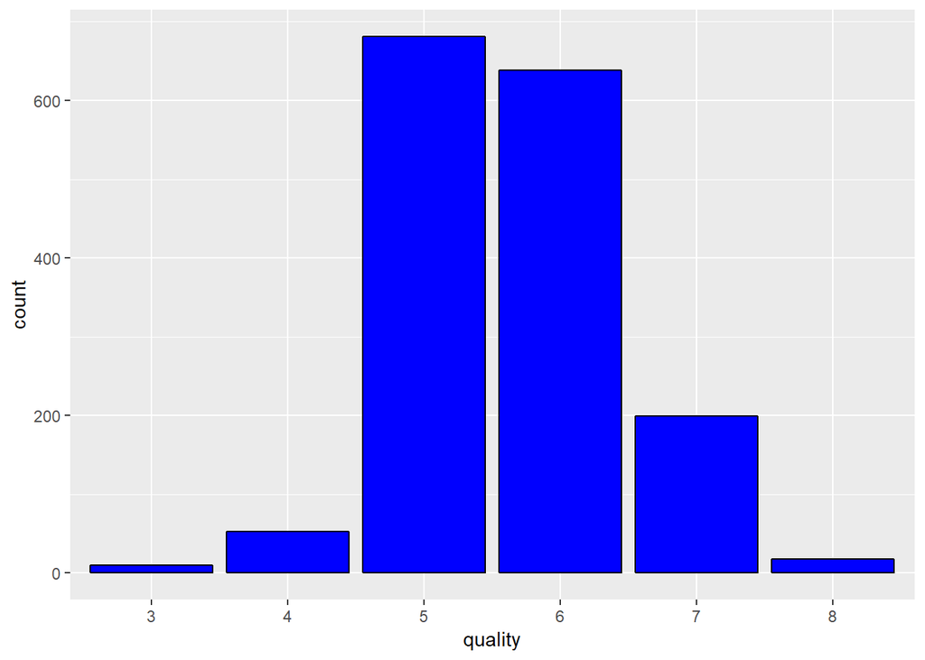

```r
#plotting distribution of Quality variable
ggplot(aes(x = quality), data = redwine) + geom_bar(color = I('black'), fill = I('#0000FF'))
```

```r
summary(redwine$quality)
```

```
##   3   4   5   6   7   8
##  10  53 681 638 199  18
```

#### Observation:

Most of data in our dataset is of Average quality wines i.e 5 and 6 as compared to Poor and Good quality wines. This may result in bias result and inaccuracy of the model of the Wine Quality

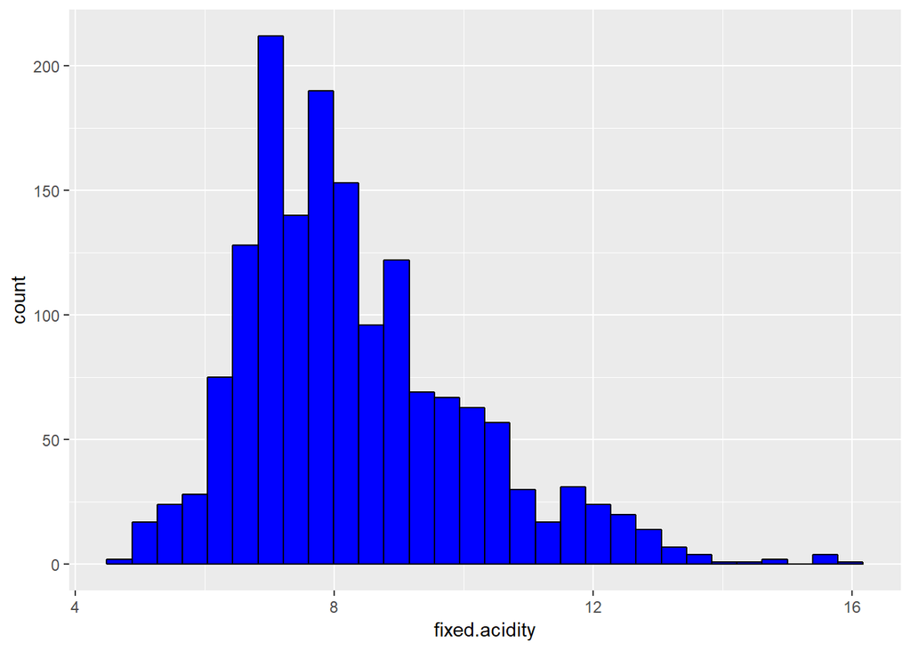

```r
#plotting distribution of fixed acidiity

ggplot(aes(x = fixed.acidity), data = redwine) + geom_histogram(color = I('black'), fill = I('#0000FF'))
```

```r
summary(redwine$fixed.acidity)
```

```
##    Min. 1st Qu.  Median    Mean 3rd Qu.    Max.
##    4.60    7.10    7.90    8.32    9.20   15.90
```

#### Observation:

Distribution of Fixed acidity in our data set is Right/Positive Skewed with Median of 7.90 and mean being dragged to 8.32 due to presence of Outliers

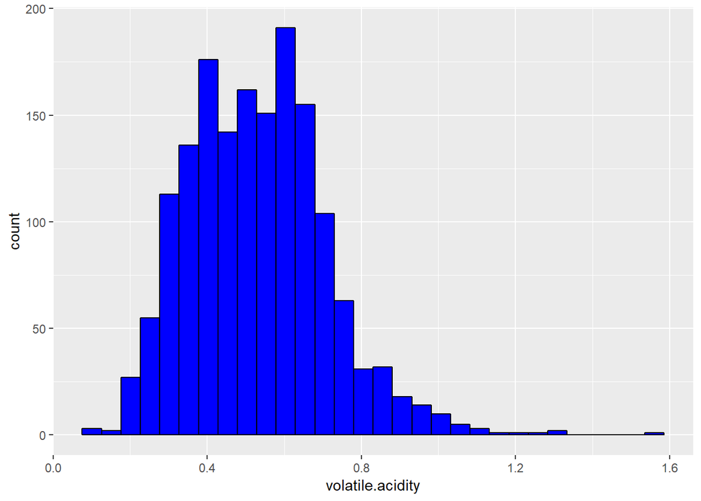

```r
ggplot(aes(x = volatile.acidity), data = redwine) + geom_histogram(color = I('black'), fill = I('#0000FF'))
```

```r
summary(redwine$volatile.acidity)
```

```
##    Min. 1st Qu.  Median    Mean 3rd Qu.    Max.
##  0.1200  0.3900  0.5200  0.5278  0.6400  1.5800
```

#### Observation:

Distribution of Volatile Acidity seems to be Bi-modal with peaks at maximum no. of wines possessing the value of 0.4 and 0.6.

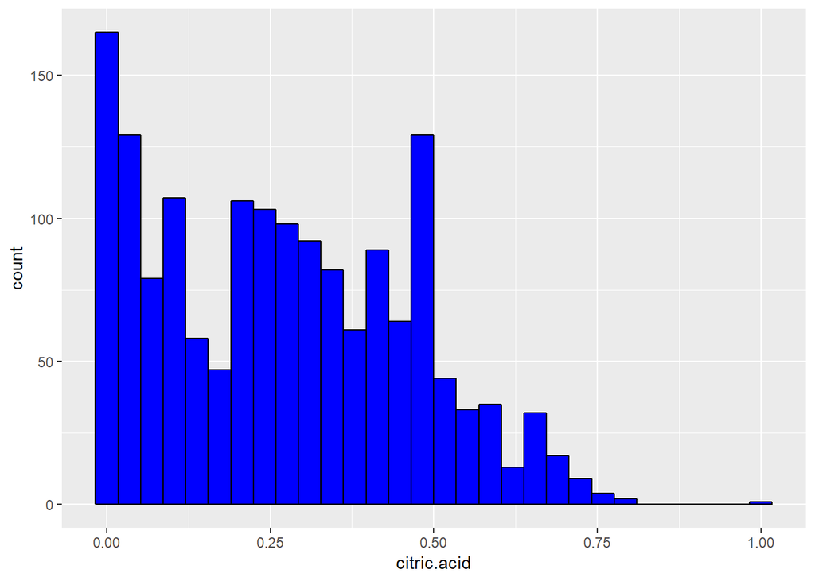

```r
ggplot(aes(x = citric.acid), data = redwine) + geom_histogram(color = I('black'), fill = I('#0000FF'))
```

```r
summary(redwine$citric.acid)
```

```
##    Min. 1st Qu.  Median    Mean 3rd Qu.    Max.
##   0.000   0.090   0.260   0.271   0.420   1.000
```

#### Observation:

Citric acid dsitribution does not seems to be following any standard dsitribution with more the two peak values. 75% of the values are less than or equal to 0.42 but maximum value of citric acid is 1.0 which signifies the presence of several outliers.

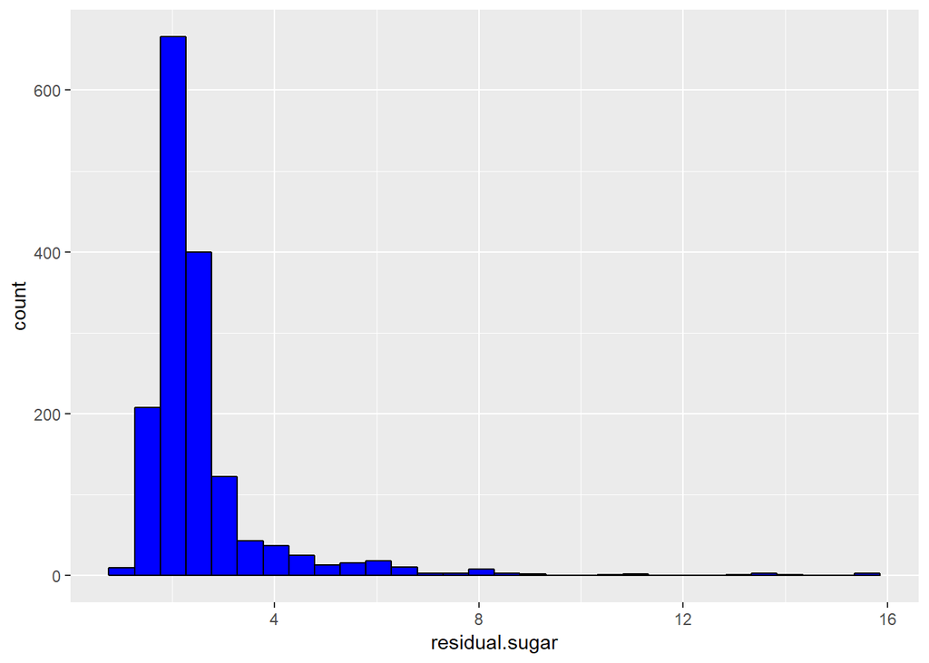

```r
ggplot(aes(x = residual.sugar), data = redwine) + geom_histogram(color = I('black'), fill = I('#0000FF'))
```

```r
summary(redwine$residual.sugar)
```

```
##    Min. 1st Qu.  Median    Mean 3rd Qu.    Max.
##   0.900   1.900   2.200   2.539   2.600  15.500
```

#### observation:

Residual sugar also seems to be Right Skewed as Fixed acidity with Mean being greater than Median due to effect of Outliers.

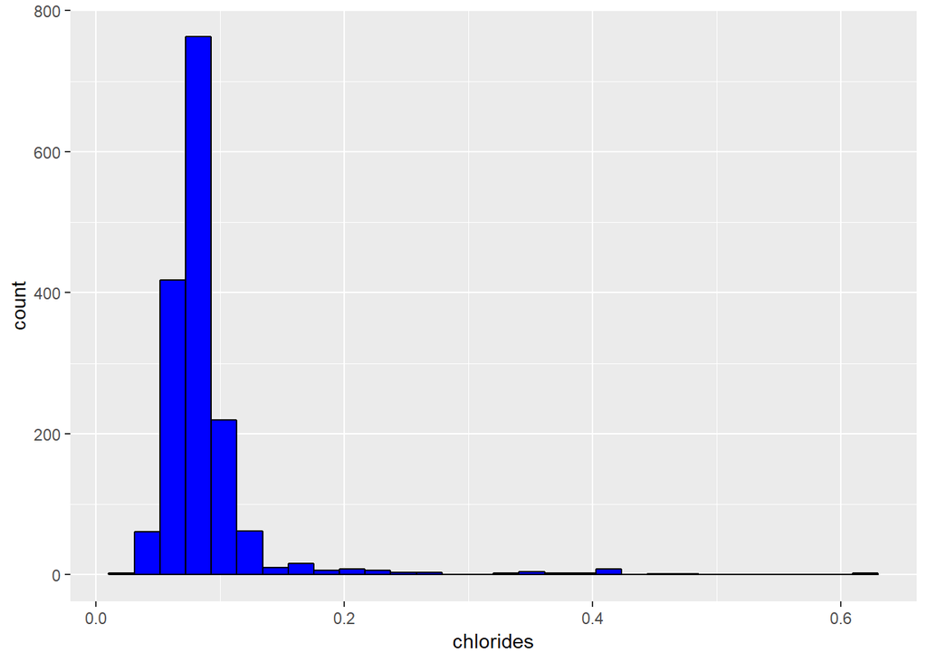

```r
ggplot(aes(x = chlorides), data = redwine) + geom_histogram(color = I('black'), fill = I('#0000FF'))
```

```r
summary(redwine$chlorides)
```

```
##    Min. 1st Qu.  Median    Mean 3rd Qu.    Max.
## 0.01200 0.07000 0.07900 0.08747 0.09000 0.61100
```

#### Observation:

Distribution of Chlorides seems to be similar to Residual sugar i.e Right Skewed due to presece of outliers.

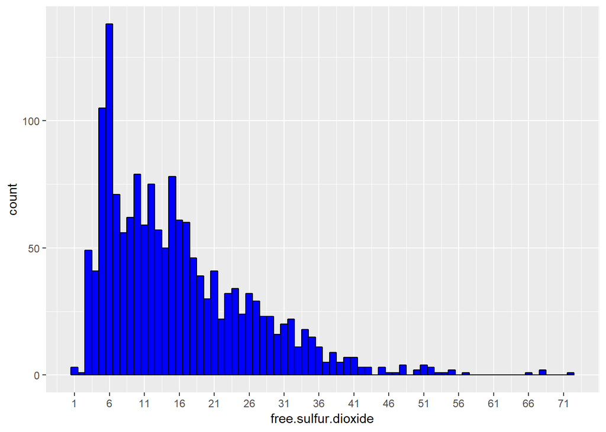

```r
ggplot(aes(x = free.sulfur.dioxide), data = redwine) + geom_histogram(color = I('black'), fill = I('#0000FF'),binwidth = 1) + scale_x_continuous(breaks = seq(1,72,5))
```

```r
summary(redwine$free.sulfur.dioxide)
```

```
##    Min. 1st Qu.  Median    Mean 3rd Qu.    Max.
##    1.00    7.00   14.00   15.87   21.00   72.00
```

#### Observation:

Free sulfur dioxide also seems to be following positive skewed distribution as most of varibles with peak value at 6.

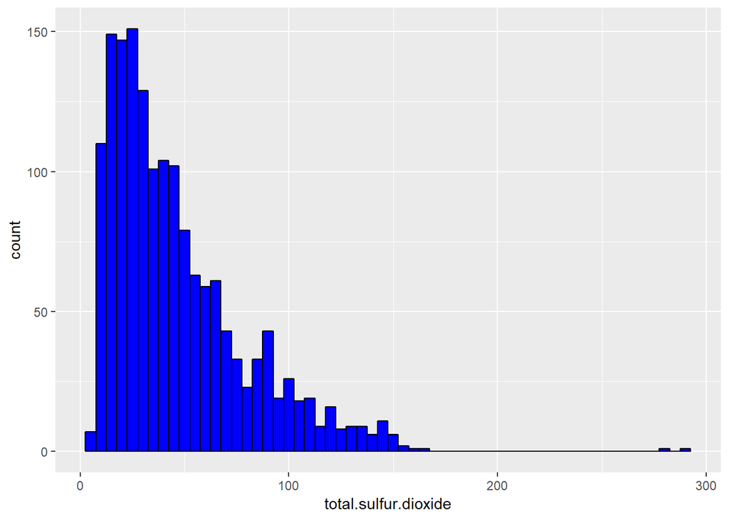

```r
ggplot(aes(x = total.sulfur.dioxide), data = redwine) + geom_histogram(color = I('black'), fill = I('#0000FF'),binwidth = 5)
```

```r
summary(redwine$total.sulfur.dioxide)
```

```
##    Min. 1st Qu.  Median    Mean 3rd Qu.    Max.
##    6.00   22.00   38.00   46.47   62.00  289.00
```

#### Observation:

Total sulfur dioxide also seems to be following similar pattern as Free sulfur dioxide.

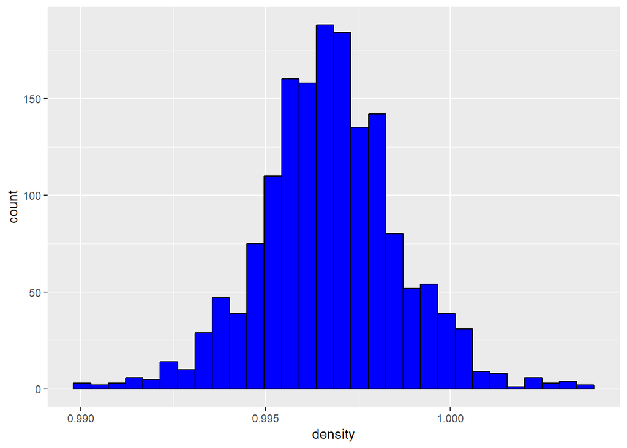

```r
ggplot(aes(x = density), data = redwine) + geom_histogram(color = I('black'), fill = I('#0000FF'))
```

```r
summary(redwine$density)
```

```
##    Min. 1st Qu.  Median    Mean 3rd Qu.    Max.
##  0.9901  0.9956  0.9968  0.9967  0.9978  1.0037
```

#### Observation:

Density seems to approximately Normally distributed with Mean and median to be 0.99

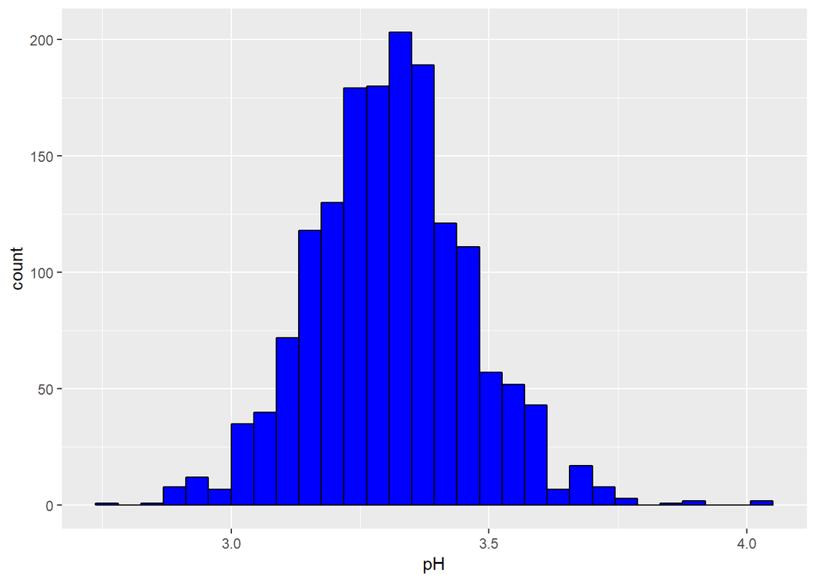

```r
ggplot(aes(x = pH), data = redwine) + geom_histogram(color = I('black'), fill = I('#0000FF'))
```

```r
summary(redwine$pH)
```

```
##    Min. 1st Qu.  Median    Mean 3rd Qu.    Max.
##   2.740   3.210   3.310   3.311   3.400   4.010
```

#### Observation:

PH distribution is also Normal similar to density

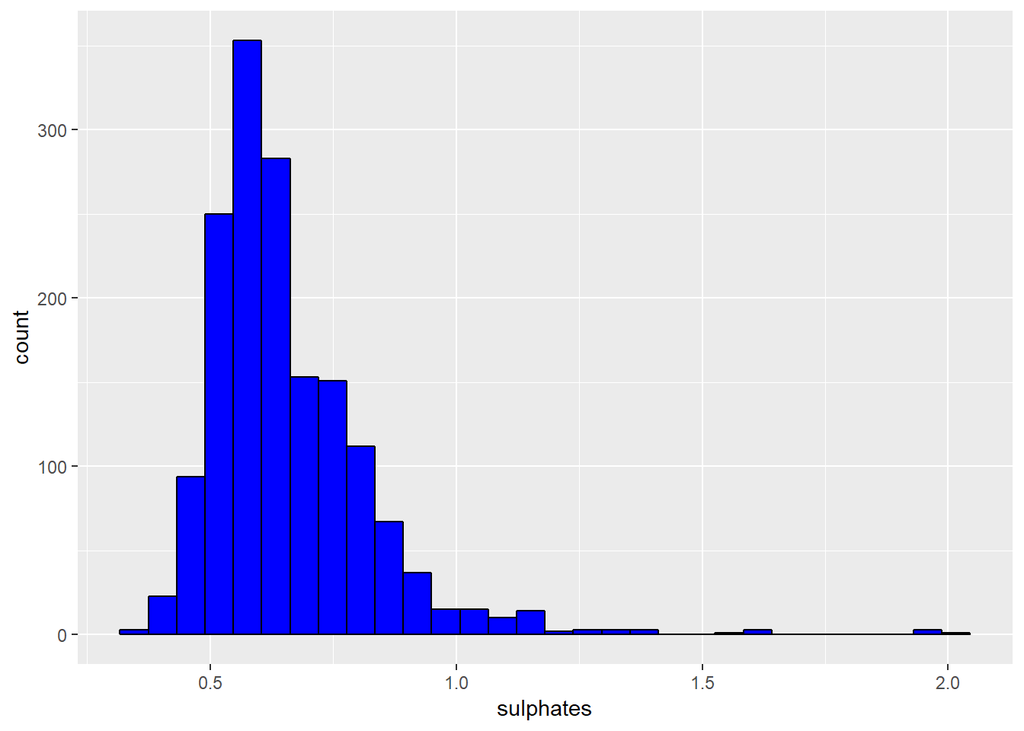

```r
ggplot(aes(x = sulphates), data = redwine) + geom_histogram(color = I('black'), fill = I('#0000FF'))
```

```r
summary(redwine$sulphates)
```

```
##    Min. 1st Qu.  Median    Mean 3rd Qu.    Max.
##  0.3300  0.5500  0.6200  0.6581  0.7300  2.0000
```

#### Observation:

Sulphates also seems to be following positive skewed distribution as most of varibles with peak value at 0.6.

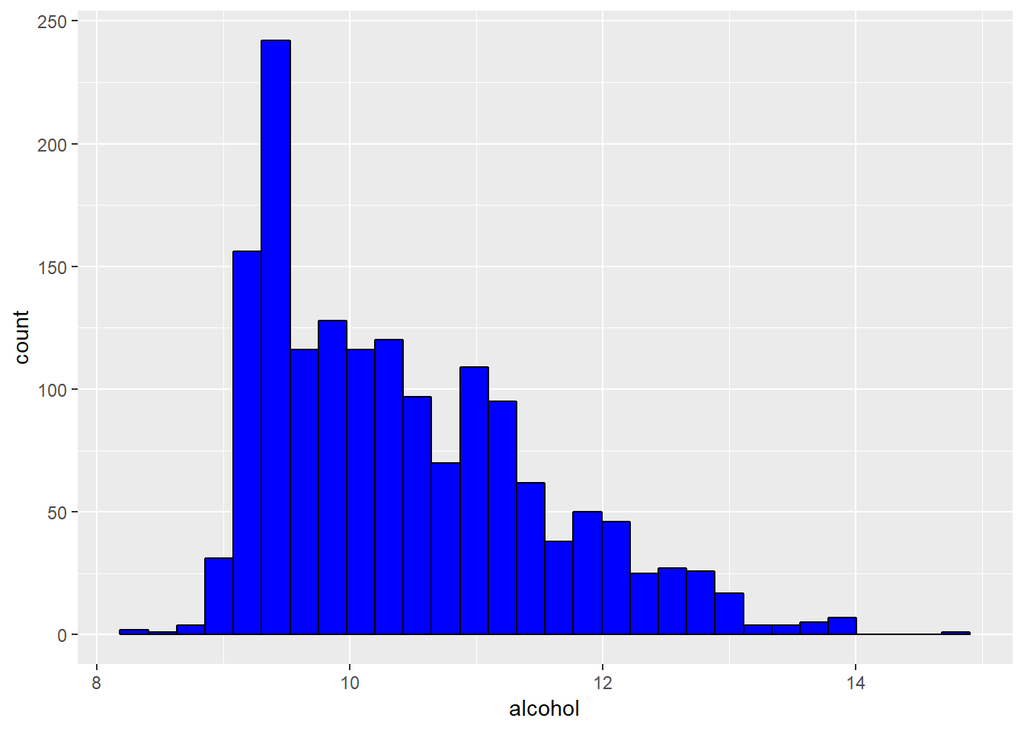

```r
ggplot(aes(x = alcohol), data = redwine) + geom_histogram(color = I('black'), fill = I('#0000FF'))
```

```r
summary(redwine$alcohol)
```

```
##    Min. 1st Qu.  Median    Mean 3rd Qu.    Max.
##    8.40    9.50   10.20   10.42   11.10   14.90
```

#### Observation:

Alcohol also seems to be right skewed but with less skewness/outliers as compared to other skewed variables.

# Univariate Plot Analysis

## What is the Structure of the dataset?

The Red wine dataset has 1599 observations of 13 variables. Out of 13, Quality is the categorical variable and rest are numerical that reflect the chemical and physical properties of the wine.

## What is/are the main feature(s) of interest in your dataset?

Main feature of interest in this dataset is the ‘Quality’. I would like to determine which factors are best to determine the quality of a wine.

## What are your thoughts before starting the analysis about the dataset?

I think ‘Alcohol’ might play a key role in determining the quality of the Red wine. Also, ‘acidity’ also may impact the quality of the wine. Considering the taste, i believe ‘residual sugar’ will also affect the quality of the red wine.

## Of the features you have investigated, what different distributions you observed for the variables in the dataset?

1. Out of all variables, only PH nad density follows teh NOrmal distribution.
2. Fixed and volatile acidity, total and free sulfur dioxides, alcohol and sulphates seem to follow right skewed due to the presence of outliers.
3. Residual sugar and Chloride seems to have more extreme outliers as compare to other variables.

# Bivariate Plot Section

I have created Correlation matrix between all the variables to get the overview that which variables may have impact on Quality and which all variables may be correlated to each other.

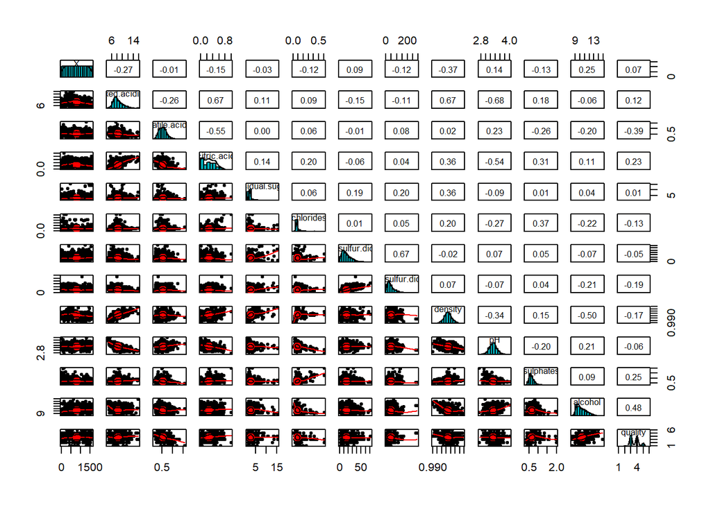

```r
#plotting correlation matrix
pairs.panels(redwine[,],method = "pearson",hist.col = "#00AFBB", density = TRUE)
```

#### Observations:

1. Density has a some significant correlation with Fixed Acidity with pearson coefficent of 0.67.
2. Volatile Acidity and Alcohol seems to be strngest factor among all to influence the Quality of the wine.
3. Alcohol has negative correlation with density which seems to fine as the density of water is greater than the density of alcohol.
4. Strangely, volatile acidity seems to have positive correlation with pH which doesnt seems to be normal as pH reduce with the acidity

Now, lets have a closer view to check which varibales are helpful in determining the Quality of the Red wine.

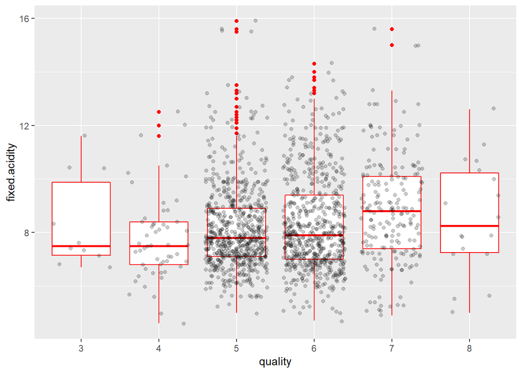

```r
#plot between quality and Fixed acidity
ggplot(aes(x = quality, y = fixed.acidity), data = redwine) + geom_boxplot(color = 'red',aplha= 1/20)+geom_jitter(alpha=1/5)
```

Plot signify that fixed Acidity doesnt have significant impact in determining the Quality of the red Wine as Median values remain approximately same with increase in quality.

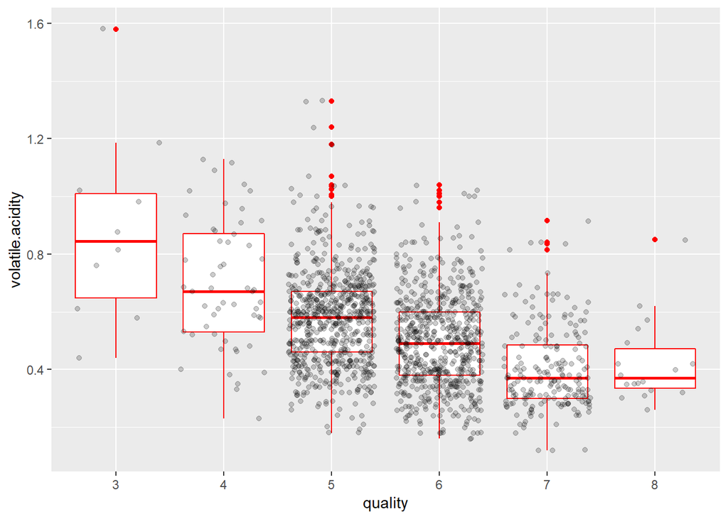

```r
#plot between quality and Volatile acidity

ggplot(aes(x = quality, y = volatile.acidity), data = redwine) + geom_boxplot(color = 'red',aplha= 1/20)+geom_jitter(alpha=1/5)
```

It clearly depicts that volatile acidity have negative correlation with quality of the wine. As the volatile acidity decreases quality of the wine increases.

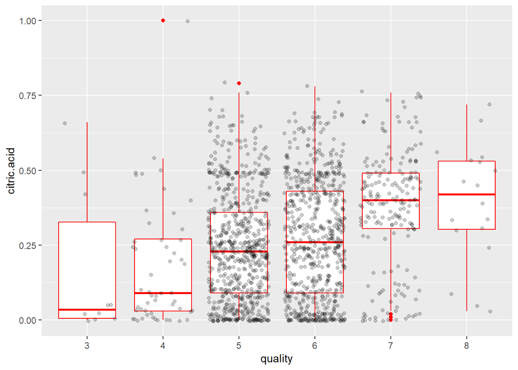

```r
ggplot(aes(x = quality, y = citric.acid), data = redwine) + geom_boxplot(color = 'red',aplha= 1/20)+geom_jitter(alpha=1/5)
```

CItric Acid also seems to be playing role in determining the quality of the red wine. Good wines are having more concentration of Citric acid.

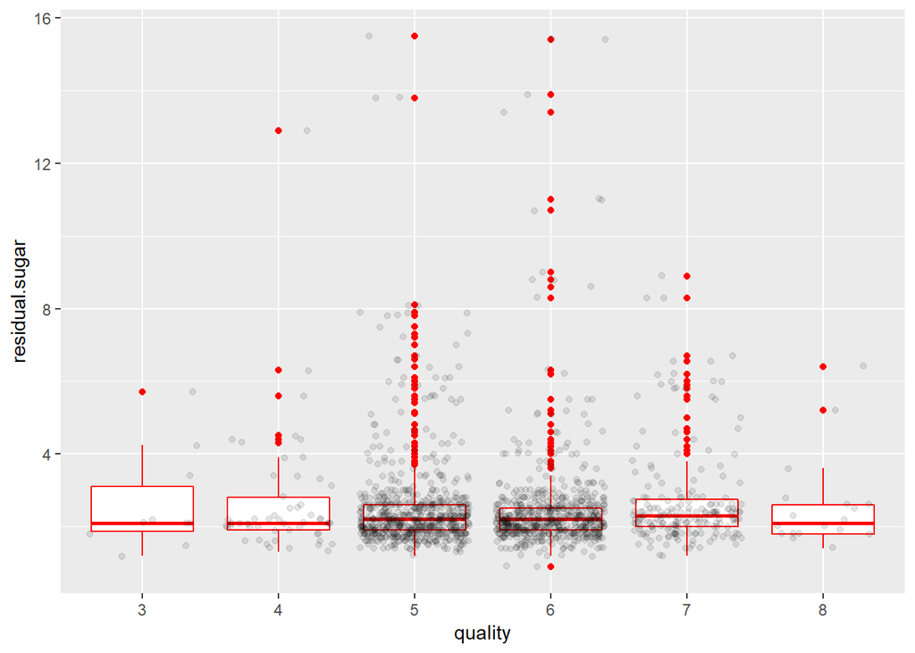

```r
ggplot(aes(x = quality, y = residual.sugar), data = redwine) + geom_boxplot(color = 'red')+geom_jitter(alpha=1/10)
```

This contradicts my initial assumption as Residual sugar seems not to be affecting the quality of the wines as median values for residual sugar are apporximately same for different quality wines.

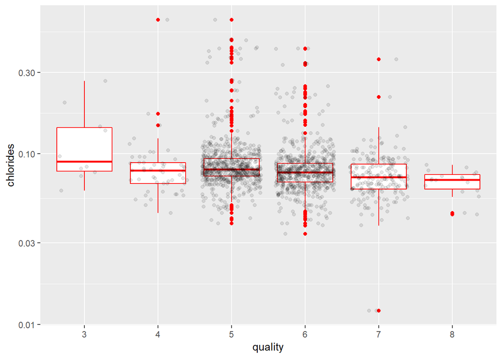

```r
#plot between quality and Chlorides

ggplot(aes(x = quality, y = chlorides), data = redwine) + geom_boxplot(color = 'red')+geom_jitter(alpha=1/10) + scale_y_log10()
```

Above plots imply that chlorides seems to be following the similar pattern as Residual sugar and have no major impact on wuality of the red wines.

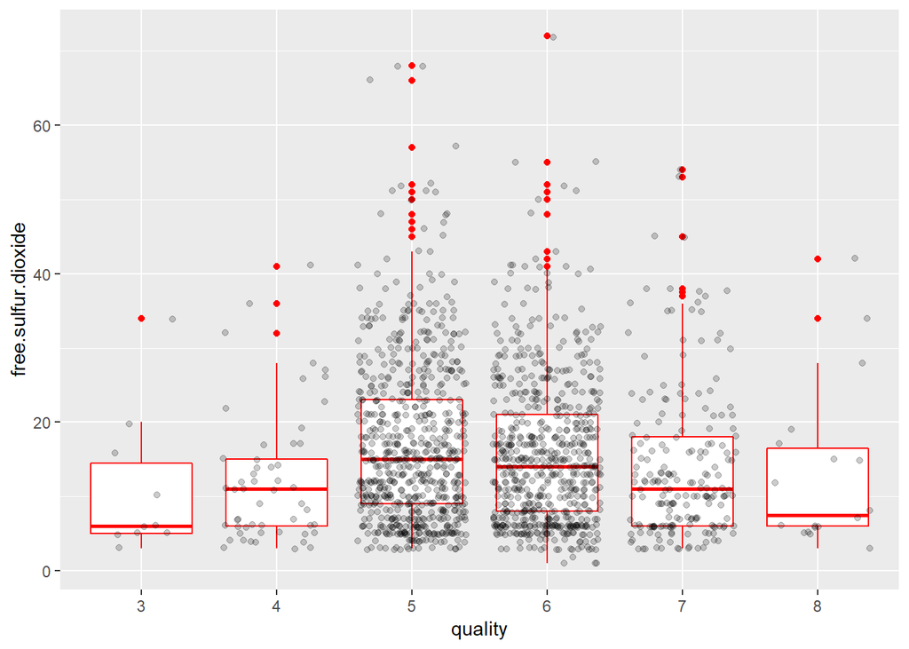

```r
ggplot(aes(x = quality, y = free.sulfur.dioxide), data = redwine) + geom_boxplot(color = 'red',aplha= 1/20)+geom_jitter(alpha=1/5)
```

Its seems to be an interesting observation, bad and good quality wines seems to have low concentration of free sulfur dioxide ,while average quality wines seems to have high conctentraion of free sulfur.

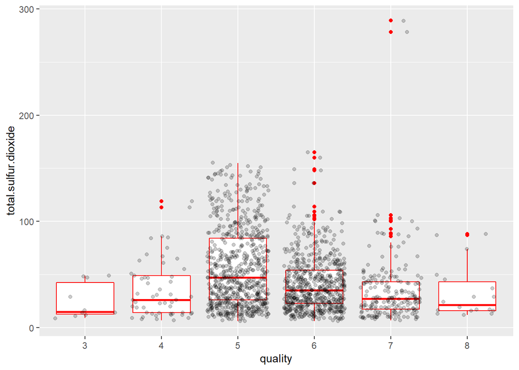

```r
#plot between quality and total sulfur dioxide

ggplot(aes(x = quality, y = total.sulfur.dioxide), data = redwine) + geom_boxplot(color = 'red',aplha= 1/20)+geom_jitter(alpha=1/5)
```

This pretty much expected, total sulfur follows the similar pattern as free sulfur

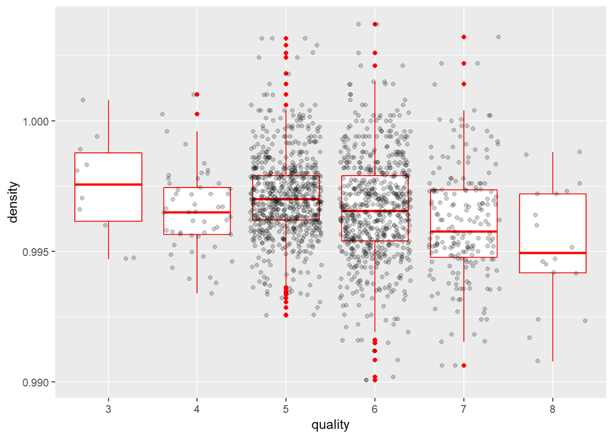

```r
ggplot(aes(x = quality, y = density), data = redwine) + geom_boxplot(color = 'red')+geom_jitter(alpha=1/5)
```

Better wines seems be less dense as compared bad quality wines. This may be due to presence high concentration of Alcohol.

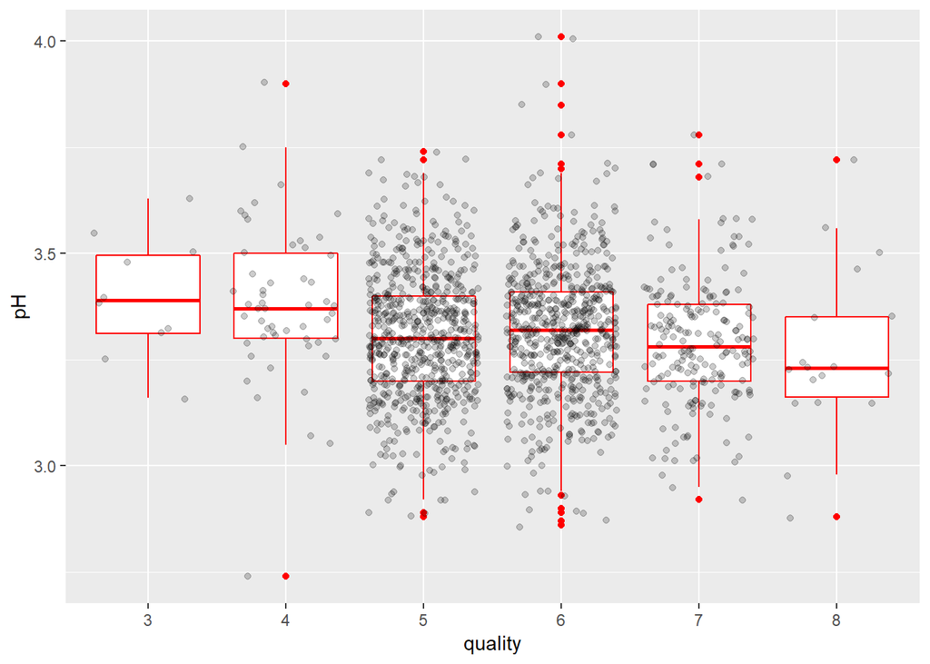

```r
ggplot(aes(x = quality, y = pH), data = redwine) + geom_boxplot(color = 'red')+geom_jitter(alpha=1/5)
```

Better wines seems to have less pH, i.e they are more acidic.

Lets check out which how various acids impact the pH

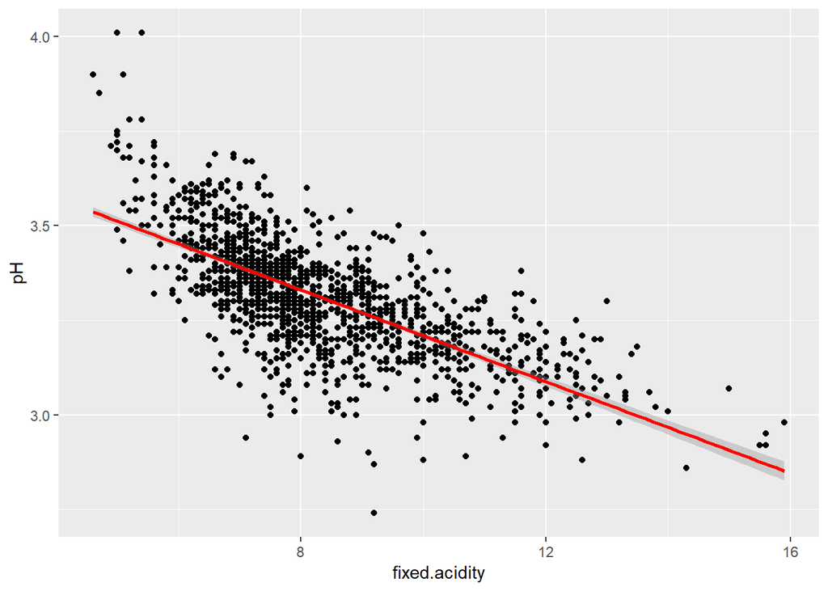

```r
#plot between pH and Fixed acidity

ggplot(aes(x = fixed.acidity,y = pH ), data = redwine) + geom_point()+geom_smooth(method = "lm",color= 'red')
```

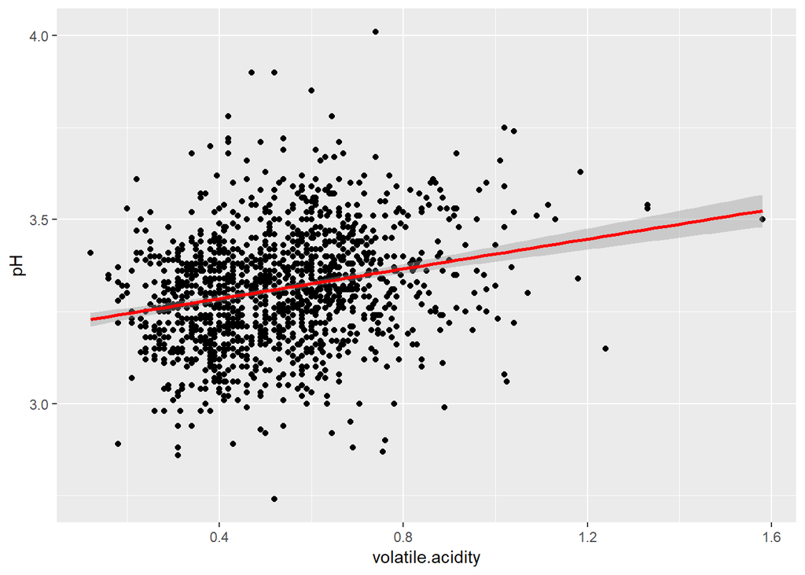

```r
ggplot(aes(x = volatile.acidity,y = pH ), data = redwine) + geom_point()+geom_smooth(method = "lm",color= 'red')
```

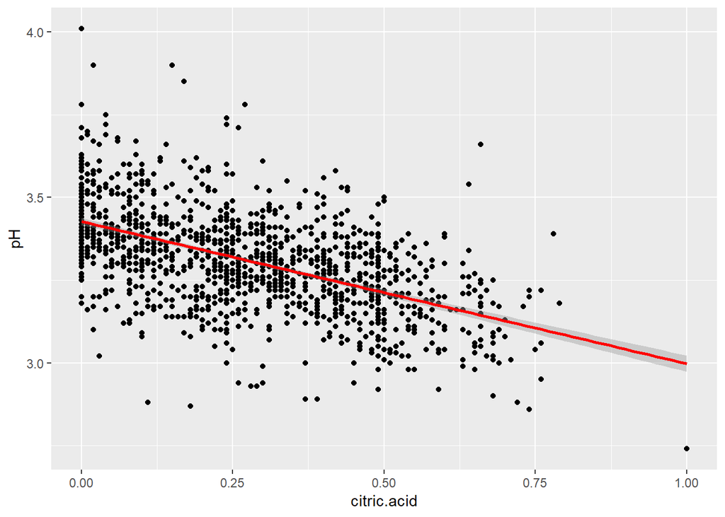

```r
ggplot(aes(x = citric.acid,y = pH ), data = redwine) + geom_point()+geom_smooth(method = "lm",color= 'red')
```

Its strange to see why volatile acidity have positive correlation with pH. It might be due to Simpson paradox or limited no, of observations.

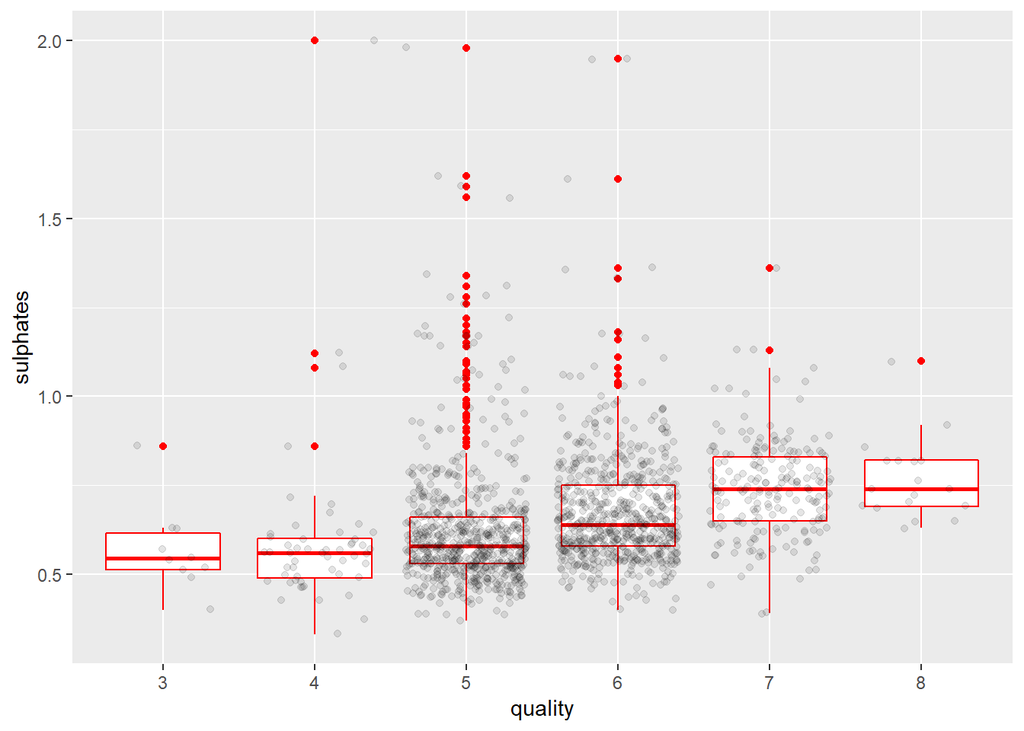

```r
#plot between quality and sulphates

ggplot(aes(x = quality, y = sulphates), data = redwine) + geom_boxplot(color = 'red')+geom_jitter(alpha=1/10)
```

It clearly depicts that better wines seems to have more concentration of sulphates

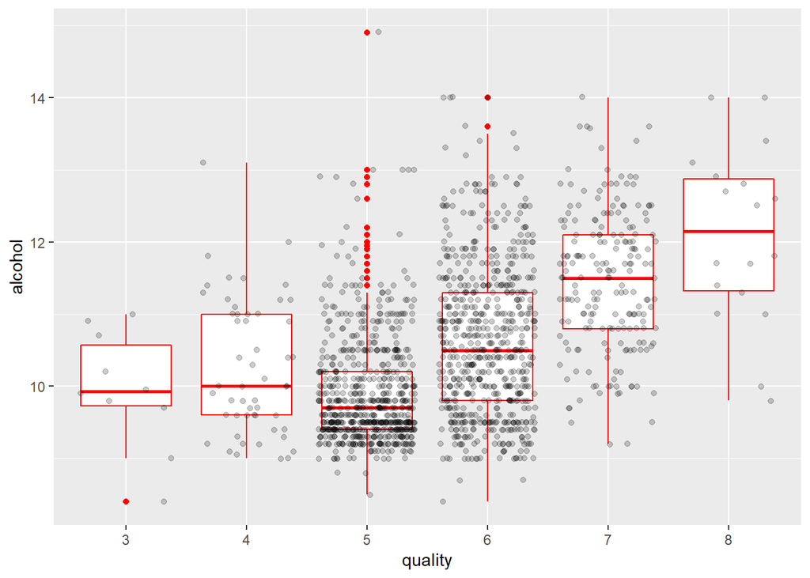

```r
ggplot(aes(x = quality, y = alcohol), data = redwine) + geom_boxplot(color = 'red')+geom_jitter(alpha=1/5)
```

It seems to be most strongest correlation among all the variables with quality of the Red WInes. It can be clearly seen that better quality wines have more concentration of Alcoholas compared to poor quality wines.

# Bivariate Analysis

## Talk about some of the relationships you observed in this part of the investigation?

1. Fixed Acidity seems to have almost no effect on quality.
2. Volatile Acidity seems to have a negative correlation with the quality.
3. Better wines seem to have higher concentration of Citric Acid.
4. Better wines seem to have higher alcohol percentages.
5. Chlorides & Residual Sugar seems to have no impact on quality of the wines.
6. Better wines seem to have lower densities. This may be due to the higher alcohol content in them.
7. Better wines seem to be more acidic.

## Did you observe any interesting relationships between the other features (not the main feature(s) of interest)?

Volatile acidity had a positive correlation with pH which was unexpected. This may be due to Simpson paradox or limited no. of observations.

## What was the strongest relationship you found?

Alcohol seems be strongest factor in determining the quality of wines with higest pearson correlation of 0.48 among all other variables.

# Multivariate Plot section

As we saw, Alcohol seems be strongest factor in determining the quality of wines. So lets plot that with other significant varibales to have deeper view.

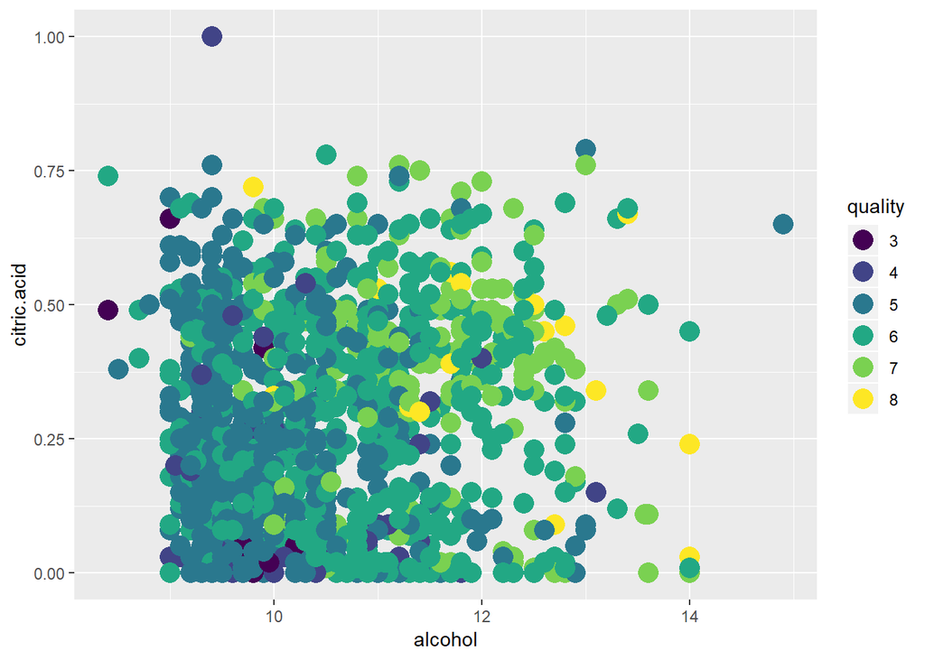

```r
#plot between alcohol and Citric acid colored by Quality

ggplot(aes(x= alcohol, y = citric.acid), data = redwine)+ geom_point(aes(color= quality), size = 5) + scale_fill_brewer(type = 'div')
```

#### Observation :

It is observed that more alcohol and more citric acid concentration seems to produce better wines.

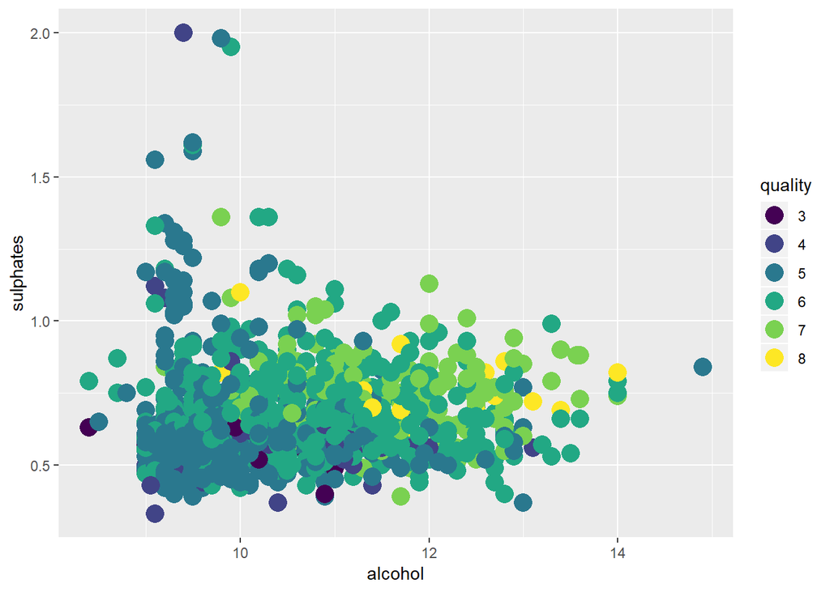

```r
ggplot(aes(x= alcohol, y = sulphates), data = redwine)+ geom_point(aes(color= quality), size = 5) + scale_fill_brewer(type = 'div')
```

#### Observation :

It is observed that more alcohol produce better wines if they have high sulphates concentration.

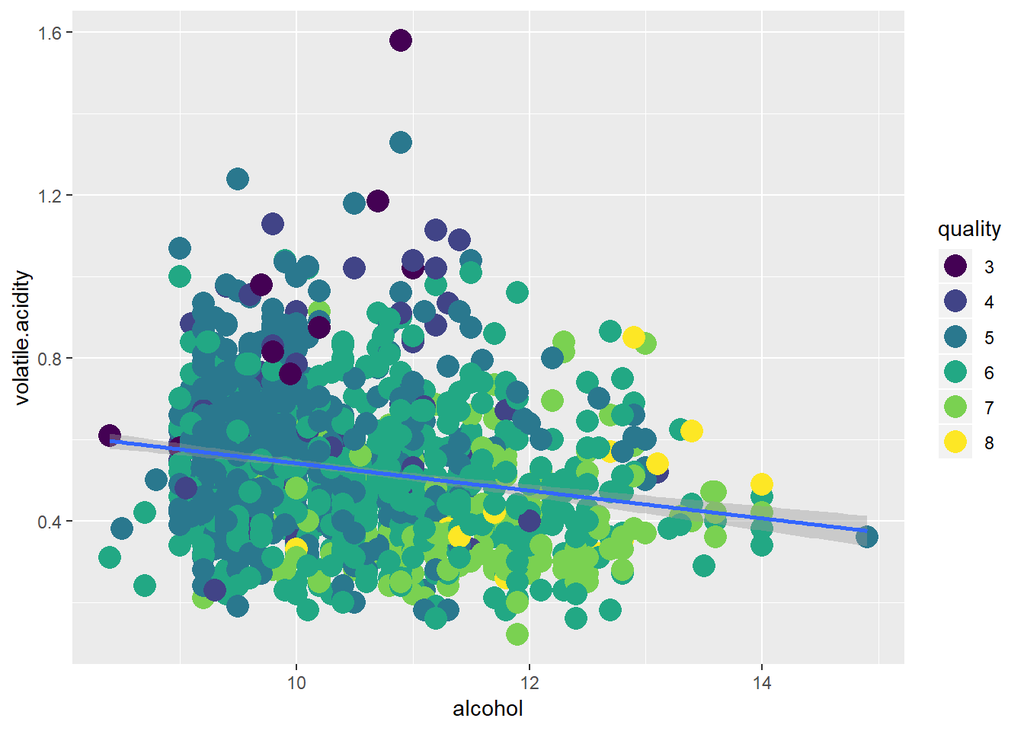

```r
#plot between alcohol and Volatile acidity colored by Quality

ggplot(aes(x= alcohol, y = volatile.acidity), data = redwine)+ geom_point(aes(color= quality), size = 5) + scale_fill_brewer(type = 'div')+geom_smooth(method = 'lm')
```

#### Observation:

This one says better wines should have high alcohol but low volatile acidity.

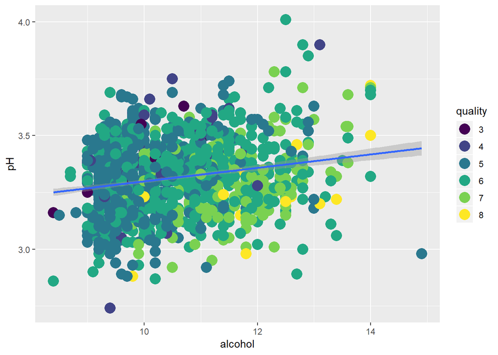

```r
ggplot(aes(x= alcohol, y = pH), data = redwine)+ geom_point(aes(color= quality), size = 5) + scale_fill_brewer(type = 'div')+geom_smooth(method = 'lm')
```